# 进阶之苦

为毛”入门”后无法涨工资

201117 2242

# 但行

## CEO

> 用了20年, 终于可以自称:
- **C**hief
- **E**vangelist
- **O**fficer

## 布道官

> 首席的…

怎么来的?

## JAVA

> 1998 江苏石油化工学院

自学->Think in JAVA

## ActionScript

> 1999, 常州利诚通讯

Flash ->

## PHP

> 2000, 上海讯博数码科技

ASP ->

## NucleusCMS

> 2001

Blogging

## CZUG

> 2002~07

Plone 1.0

[figure not shown]

## 啄木鸟

> 2003~
- MoinMoin 1.4.*
- -> Zim
- -> -> Notational Velocity
- -> -> -> ScrapBook

## CPUG

> 2004 ~ SINA.com

FreeBSD

## BPUG

> 2005 ~ 08

47期会课

## ZPUG

> 2007 ~ 2009

BPUG…

## ECUG

> 2007 ~ 金山
- Erlang
- erlbattle
- 2010->实效云用户组

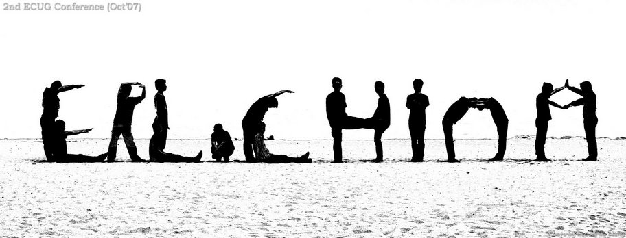

ECUG II

## sociallearnlab.org

> 教育大发现 2008 ~ 2013

社区顾问

## TechParty.org

> 珠三角技术沙龙 2009 ~

ZPUG ->

## PyCon Asia Pacific

> 2010 新加坡

[PythoniCamp](https://wiki.woodpecker.org.cn/moin/PyCon2010)

## PyCon中国

> 2011 ~ PyConChina

自己的 conference

## [开源卫士](http://code.ijinshan.com/)

> 2012~13 49期讲座
- golang
- node.js
- OpenResty
- crx.
- SAE
- …

## GDG 珠海

> 2013 ~

GCP … G+

## COSCUP

> 2014

主题+闪电

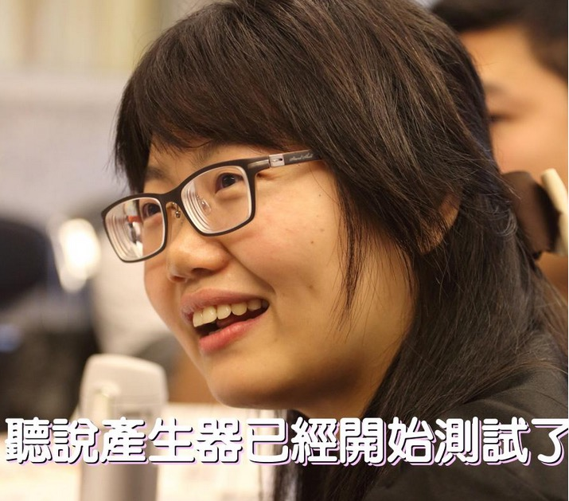

委员长图文产生器

## OSTC14

> 但行好事, 莫问前程

## OSTC15

> 程序媛专场主持

> > Mr. 大妈

## OMOOC.py

> 2015~18

有偿

## 自怼圈

> 170401 ~ 小密圈…

知识付费

## 101.camp

> 181225 ~ 蟒营™课程

服务大众

自筑社群

## TFUG 珠海

> 190214 ~

AI 落地

## 눈_눈

> 提醒

[figure not shown]

Zzz…

# 好事

## 管理

> 过程改进

用**技术**改善**技术人**生活品质

## 写作

> 爱好

22CC

> > 28年前…

## 社区

> GNU 感召
- 进入
- 理解
- 服务
- 发起
- 策划
- etc.

## 社群

> 社区群落 ~> 领域流量
- 有关联
- 场景向
- 自运营
- …

## 自怼

> DebugUself

有心无心,自然聚集

[figure not shown]

the force…

## OBP

> 设计

[figure not shown]

## 工程

> [如何组织在线图书工程 · OpenBookProjects/wiki](https://github.com/OpenBookProjects/wiki/blob/master/HowToBuildBookOnline.md)

[figure not shown]

## 社区

> 高于图书

[figure not shown]

## 눈_눈

> 提醒

[figure not shown]

kcn_dftba.jpg (JPEG Image, 5400 × 7200 pixels) - Scaled (18%)

# 莫问

## Levels

> 知识层级

## Unknow Unknow

> 不知己不知

## Unknow Know

> 不知己知何

## Know Knowed

> 知己何已知

## Know Unknow

> 知己何不知

[figure not shown]

[拙见/ 什么是网课?](https://mp.weixin.qq.com/s/sYTdj0r9b9WTDJBYCkae3w)

## 为什么

> 学会了编程也没加薪?

## 什么是

> 会编程?

## 编程

> 是什么?

## 程序

> 又是什么?

## 为什么

> 要编写程序?

## 所以

> 为什么而编程?

## 也就是说

> 别人凭什么为我们的代码付费?

## 会编程

> 有自信:

```
将任何问题
    分解为
        当前自己
    能力范畴以内
子问题序列.
```

## 靠谱

> Kaopulity

## Kaopulity

- **K**eep
- **a**ll
- **o**f
- **p**rocesses
- **u**sabi**lity**

## 极端点

> 如果自己代码赚到钱时,

就是加薪之日

## 눈_눈

> 提醒

[figure not shown]

kcn_export_now.jpg (JPEG Image, 564 × 840 pixels)

# 前程

## 无忧解

[figure not shown]

## 五大定律

> 和普通人相关的只有:
- 成功可以发⽣在任何时间和年龄，
- 只要你在⼀个好想法上坚持不懈。

## 千万别坚持

> 坚持等于忍受

忍受无法长久…

[figure not shown]

## Feynman Technique

> 史上最强
- 指定概念
- 假设教授
- 说不通顺->复习
- 简化陈述->用自己的话

[figure not shown]

Σωκράτης

## 热情

兴趣和内在动机才是长期坚持的动力

- 教育不是灌输, 而是**点燃**火熖
- 教育最有效的方法不是告诉答案,
- 而是向他们提问!

- ```
  --- Σωκράτης (Socrates)
  ```

## 文档

> 目标应该是什么?

## Aristotle

> “For the things we have to learn before we can do them, we learn by doing them.”

## 亚里士多德

> “我们通过做来学习

> 我们必须学习去做的…”

~ 伦理学

## 编撰

> 高质量技术文章

## 长征

> 终点不是会宁
- 大家都**会**用了
- 社区就**宁**静了

## 起点

> 高质量技术文章

只是起点

## 无尽的修订

> 嘦社区/项目/工程/软件/..在发展
- 宣传文章
- 技术文档
- 社区图书
- …不能停

## 如何

> 编撰高质量技术文章?
- 能自信
  - 将文章分解为
  - 当前能力范畴内
  - 子问题序列

## 框架

> 原来/应该/最好/…
- 论文
- 帮助手册
- hand first …

## 5W1H

> 最基本, 自己想看什么
- Who
- When
- Where
- What
- Why
- How

## 最囧

> 编撰高质量技术文章时…
- 术语
- 无代码
- 埋梗…

## 目标

> 好文章习以为常
- **习惯用**文章表述论战
- **习惯以**文档回答问题
- **习惯对**文档持续增补
- …

[figure not shown]

## 发布

> 立即

[figure not shown]

## 效益

> 输出是更残酷的输入

读者0..

## 什么是知识?

> 经验在组织内流通的速率

## 原理

> 知.时合一

[figure not shown]

## SNS

> 基于网络学习

[figure not shown]

## 问题是

> 别人为什么要与你连接?

## 因为…

[figure not shown]

## 其实

> 自学并不难…
- 网络资源无穷
- 中国人自学力 MAX

## 但是

> 独自时, 难以:

…

## 难以

- 短期密集学习
- 作品输出导向
- 大强度持续练

> > 三从一大

## 最难

> 好/对/真/价值/…问题序列

## 同侪压力

> 被动进步才最效率

## 极客时间

> 有值得的
- [许式伟的架构课](https://time.geekbang.org/column/intro/166)
- [左耳听风](https://time.geekbang.org/column/intro/100002201)
- …

## 目标

> 写出同级课程

[Python进阶训练营](https://u.geekbang.org/subject/python/1000389)

## 눈_눈

> 提醒

[figure not shown]

Zzz…

# (￣▽￣)

## 눈_눈

> 提醒

[figure not shown]

askdama@googlegroups.com

[figure not shown]

微信+公众号: ZoomQuiet

## 幻灯

> NOT PPT

[slides.101.camp/geek2py](http://slides.101.camp/geek2py.html)

## 高桥流

> [2007_高橋征義_tw.mp4](http://0.zoomquiet.top/ZQCollection/2007_%E9%AB%98%E6%A9%8B%E5%BE%81%E7%BE%A9_tw.mp4)

## 特点

## 字大

## 页多

## 翻的快

## 主要得听

## 是也乎

- 201122 speech
- 201118 fix some words
- 201117 re-factory
- 200321 speech
- 200317 append
- 200311 confirmed
- 200308 title
- 200301 init.